# MachineLearningStrategy

## Machine Learning for Stock Trading

### Part IV - Machine Learning Strategy

```python
import numpy as np
import pandas as pd
import datetime as dt
import matplotlib.pyplot as plt
from util import get_data, getbenchmark
from marketsim import compute_portvals
from indicators import getSMA, getBB, getmomentum
from ManualStrategy import manualstrategy
import StrategyLearner as sl
import warnings
warnings.filterwarnings('ignore')
```

**Framing the trading problem as machine learning problem**

- Simple Moving Average: Simple moving average (SMA) smooths out past price data. It calculates the rolling mean price of a stock for specified lookback periods. If stock prices move significantly from SMA, price tends to come back to SMA. Strategy is to buy stock when stock price falls significantly below the SMA and to short the stock when stock price rise significantly above SMA. We calculate the ratio of price to SMA and buy a stock when price to SMA ratio is below threshold and sell a stock when price to SMA ratio is above threshold.
- Bollinger Bands: Bollinger Bands detects the volatility and dynamics of the price movement in the stock price. Using Bollinger Bands, we can predict whether current trend in the stock price will continue or turn around. If the price is close to or outside of the upper band, the stock price would be considered high and we should sell the stock. On the other hand, if the price is near the lower band, stock price would be considered low and we should buy the stock. Middle Band = SMA with look back window of 20 days Upper Band = SMA + (2 x standard deviation of price) Lower Band = SMA - (2 x standard deviation of price) %B = (Current Price - Lower Band) / (Upper Band - Lower Band)
- Momentum: This technical indicator help us to predict strength of a price movement. Momentum is calculated by comparing the most recent closing price to a previous closing price over the lookback window. M = CP – CPn Where M is momentum, CP is closing price and n is lookback window. When the Momentum crosses above the zero-line stock price is reversing and price is bottomed out hence it is a buy signal. When the Momentum crosses below the zero-line stock price is reversing and price is topped out hence it is a sell signal.

**Training Phase:** To train the learner stock prices indexed by trading days are fed and learner creates the data frame (trainX) with 3 indicators as independent variables. Learner also creates a data frame (trainY) to represent 3 classes of dependent variables. Three classes 1, -1 and 0 in trainY represents LONG, SHORT and DO NOTHING positions.  
**Testing Phase:** In this phase learner is giving out of sample prices data for a stock and using the three technical indicators, learner predicts the action (1, -1 or 0) which will maximize the value of portfolio.  
**Discretization:** Random Tree learner classify the independent variables into various class of dependent variables and hence we do not need to discretize the data fed to learning algorithm. Random Tree learner built in previous project was can be reused in this project by changing median to mode to accommodate classification of input data. No discretization (standardization) is required for this implementation.

**Comparision of Manual Strategy vs Machine Learning Strategy**

```
Cumulative Return of Benchmark: 0.0123

Standard Deviation of Benchmark: 0.0170043662712

Average Daily Return of Benchmark: 0.000168086978191

Cumulative Return of Manual Strategy Portfolio: 0.5573

Standard Deviation of Manual Strategy Portfolio: 0.0207614156378

Average Daily Return of Manual Strategy Portfolio: 0.00109325593932

Cumulative Return of Strategy Learner Portfolio: 2.2479

Standard Deviation of Strategy Learner Portfolio: 0.00829047110324

Average Daily Return of Strategy Learner Portfolio: 0.00239760697169
```

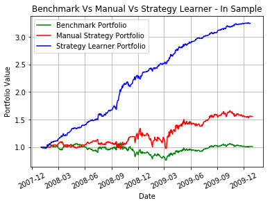

```python
 # In Sample Charts
startdt = dt.datetime(2008,1,1)
enddt = dt.datetime(2009,12,31)
symbols = 'JPM'
startval = 100000
commission = 0.0
impact = 0.0

# Benchmark
benchmark = getbenchmark(symbols, startdt, enddt, startval, commission, impact)
benchmarkportval = compute_portvals(benchmark,start_val=startval,commission=commission,impact=impact)
normedbenchmarkportval = benchmarkportval/benchmarkportval.ix[0]

daily_ret = (normedbenchmarkportval / normedbenchmarkportval.shift(1)) - 1
cr = (normedbenchmarkportval[-1] / normedbenchmarkportval[0]) - 1
adr = daily_ret.mean()
sddr = daily_ret.std()

print "Cumulative Return of Benchmark: {}".format(cr)
print
print "Standard Deviation of Benchmark: {}".format(sddr)
print
print "Average Daily Return of Benchmark: {}".format(adr)
print

# Manual Strategy Learner
manualstratdf = manualstrategy(symbols, startdt, enddt, startval, commission, impact)
manstratportval = compute_portvals(manualstratdf,start_val=startval,commission=commission,impact=impact)
normedmanstratportval = manstratportval/manstratportval.ix[0]

daily_ret = (normedmanstratportval/normedmanstratportval.shift(1)) - 1
cr = (normedmanstratportval[-1]/normedmanstratportval[0]) - 1
adr = daily_ret.mean()
sddr = daily_ret.std()

print "Cumulative Return of Manual Strategy Portfolio: {}".format(cr)
print
print "Standard Deviation of Manual Strategy Portfolio: {}".format(sddr)
print
print "Average Daily Return of Manual Strategy Portfolio: {}".format(adr)
print


# Strategy Learner
stratlearner = sl.StrategyLearner()
stratlearner.addEvidence(symbols, startdt, enddt, startval)
stratlearndf = stratlearner.testPolicy(symbols, startdt, enddt, startval)

stratlearnport = pd.DataFrame(0, index = stratlearndf.index, columns = ["Symbol", "Order", "SharesCnt"])
stratlearnport['Date'] = stratlearndf.index
stratlearnport['Symbol'] = 'JPM'
stratlearnport['Order'] = "BUY"
for i in range(0, len(stratlearndf)-1):
    if stratlearndf.ix[i]['JPM'] == 1000:
        stratlearnport.ix[i,'Order'] = 'BUY'
        stratlearnport.ix[i,'SharesCnt'] = 1000
    elif stratlearndf.ix[i]['JPM'] == 2000:
        stratlearnport.ix[i,'Order'] = 'BUY'
        stratlearnport.ix[i,'SharesCnt'] = 2000
    elif stratlearndf.ix[i]['JPM'] == -1000:
        stratlearnport.ix[i,'Order'] = 'SELL'
        stratlearnport.ix[i,'SharesCnt'] = 1000
    elif stratlearndf.ix[i]['JPM'] == -2000:
        stratlearnport.ix[i,'Order'] = 'SELL'
        stratlearnport.ix[i,'SharesCnt'] = 2000
    else:
        stratlearnport.ix[i,'Order'] = 'NOTHING'
        stratlearnport.ix[i,'SharesCnt'] = 0

stratlernportval = compute_portvals(stratlearnport,start_val=startval,commission=commission,impact=impact)
normedstratlernportval = stratlernportval/stratlernportval.ix[0]

daily_ret = (normedstratlernportval/normedstratlernportval.shift(1)) - 1
cr = (normedstratlernportval[-1]/normedstratlernportval[0]) - 1
adr = daily_ret.mean()
sddr = daily_ret.std()

print "Cumulative Return of Strategy Learner Portfolio: {}".format(cr)
print
print "Standard Deviation of Strategy Learner Portfolio: {}".format(sddr)
print
print "Average Daily Return of Strategy Learner Portfolio: {}".format(adr)
print


plt.figure(0)
plt.plot(normedbenchmarkportval, color='green', label='Benchmark Portfolio')
plt.plot(normedmanstratportval, color='red', label='Manual Strategy Portfolio')
plt.plot(normedstratlernportval, color='blue', label='Strategy Learner Portfolio')
plt.title('Benchmark Vs Manual Vs Strategy Learner - In Sample')
plt.ylabel('Portfolio Value')
plt.xlabel('Date')
plt.xticks(rotation=25)
plt.grid(True)
plt.legend()
plt.show()
```

Below table and graph shows the performance of benchmark, manual learner and strategy learner. It can be observed that Strategy Learner performed much better than Manual Strategy when compared to portfolio benchmark for in sample data.

```
Cumulative Return of Benchmark: -0.133735094307

Standard Deviation of Benchmark: 0.00878073516334

Average Daily Return of Benchmark: -0.000246878193339

Cumulative Return of Manual Strategy Portfolio: 0.0124042342213

Standard Deviation of Manual Strategy Portfolio: 0.0078566723877

Average Daily Return of Manual Strategy Portfolio: 5.52980663138e-05

Cumulative Return of Strategy Learner Portfolio: 0.705405687866

Standard Deviation of Strategy Learner Portfolio: 0.00565058801899

Average Daily Return of Strategy Learner Portfolio: 0.00108836742628
```

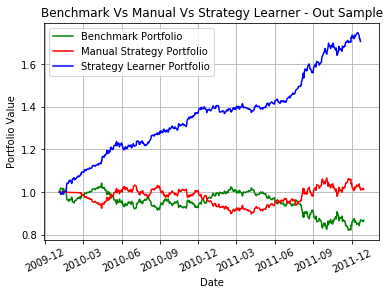

```python
# Out Sample Charts
startdt = dt.datetime(2010,1,1)
enddt = dt.datetime(2011,12,31)
symbols = 'JPM'
startval = 100000
commission = 9.95
impact = 0.005

# Benchmark
benchmark = getbenchmark(symbols, startdt, enddt, startval, commission, impact)
benchmarkportval = compute_portvals(benchmark,start_val=startval,commission=commission,impact=impact)
normedbenchmarkportval = benchmarkportval/benchmarkportval.ix[0]

daily_ret = (normedbenchmarkportval / normedbenchmarkportval.shift(1)) - 1
cr = (normedbenchmarkportval[-1] / normedbenchmarkportval[0]) - 1
adr = daily_ret.mean()
sddr = daily_ret.std()

print "Cumulative Return of Benchmark: {}".format(cr)
print
print "Standard Deviation of Benchmark: {}".format(sddr)
print
print "Average Daily Return of Benchmark: {}".format(adr)
print

# Manual Strategy Learner
manualstratdf = manualstrategy(symbols, startdt, enddt, startval, commission, impact)
manstratportval = compute_portvals(manualstratdf,start_val=startval,commission=commission,impact=impact)
normedmanstratportval = manstratportval/manstratportval.ix[0]

daily_ret = (normedmanstratportval/normedmanstratportval.shift(1)) - 1
cr = (normedmanstratportval[-1]/normedmanstratportval[0]) - 1
adr = daily_ret.mean()
sddr = daily_ret.std()

print "Cumulative Return of Manual Strategy Portfolio: {}".format(cr)
print
print "Standard Deviation of Manual Strategy Portfolio: {}".format(sddr)
print
print "Average Daily Return of Manual Strategy Portfolio: {}".format(adr)
print


# Strategy Learner
stratlearner = sl.StrategyLearner()
stratlearner.addEvidence(symbols, startdt, enddt, startval)
stratlearndf = stratlearner.testPolicy(symbols, startdt, enddt, startval)

stratlearnport = pd.DataFrame(0, index = stratlearndf.index, columns = ["Symbol", "Order", "SharesCnt"])
stratlearnport['Date'] = stratlearndf.index
stratlearnport['Symbol'] = 'JPM'
stratlearnport['Order'] = "BUY"
for i in range(0, len(stratlearndf)-1):
    if stratlearndf.ix[i]['JPM'] == 1000:
        stratlearnport.ix[i,'Order'] = 'BUY'
        stratlearnport.ix[i,'SharesCnt'] = 1000
    elif stratlearndf.ix[i]['JPM'] == 2000:
        stratlearnport.ix[i,'Order'] = 'BUY'
        stratlearnport.ix[i,'SharesCnt'] = 2000
    elif stratlearndf.ix[i]['JPM'] == -1000:
        stratlearnport.ix[i,'Order'] = 'SELL'
        stratlearnport.ix[i,'SharesCnt'] = 1000
    elif stratlearndf.ix[i]['JPM'] == -2000:
        stratlearnport.ix[i,'Order'] = 'SELL'
        stratlearnport.ix[i,'SharesCnt'] = 2000
    else:
        stratlearnport.ix[i,'Order'] = 'NOTHING'
        stratlearnport.ix[i,'SharesCnt'] = 0

stratlernportval = compute_portvals(stratlearnport,start_val=startval,commission=commission,impact=impact)
normedstratlernportval = stratlernportval/stratlernportval.ix[0]

daily_ret = (normedstratlernportval/normedstratlernportval.shift(1)) - 1
cr = (normedstratlernportval[-1]/normedstratlernportval[0]) - 1
adr = daily_ret.mean()
sddr = daily_ret.std()

print "Cumulative Return of Strategy Learner Portfolio: {}".format(cr)
print
print "Standard Deviation of Strategy Learner Portfolio: {}".format(sddr)
print
print "Average Daily Return of Strategy Learner Portfolio: {}".format(adr)
print


plt.figure(0)
plt.plot(normedbenchmarkportval, color='green', label='Benchmark Portfolio')
plt.plot(normedmanstratportval, color='red', label='Manual Strategy Portfolio')
plt.plot(normedstratlernportval, color='blue', label='Strategy Learner Portfolio')
plt.title('Benchmark Vs Manual Vs Strategy Learner - Out Sample')
plt.ylabel('Portfolio Value')
plt.xlabel('Date')
plt.xticks(rotation=25)
plt.grid(True)
plt.legend()
plt.show()
```

**Comprision of Learning Agent's Perfromance for various impact values**

**Hypothesis:** Since impact is the cost for every buy/sell transaction, it inversely proportional to the portfolio value. It can be safely assumed that lower the impact higher the performance of portfolio.

In this experiment we run the strategy learner with changing the value of impact and analyzed the effect on the in sample trading behavior and learner’s performance. We compare Cumulative Return, Standard Deviation and Average Daily Return for multiple values of impact. This experiment is carried out for following data –

- Stock: JPM
- In sample period: January 1, 2008 to December 31 2009.
- Out of sample period: January 1, 2010 to December 31 2011.
- Starting cash: 100,000.
- Allowable positions: 1000 shares long, 1000 shares short, 0 shares.
- Commission: 0.00
- Impact: 0.0, 0.005, 0.01, 0.015, 0.02 and 0.025

```
Impact: 0.0

Cumulative Return of Strategy Learner Portfolio: 2.4271

Standard Deviation of Strategy Learner Portfolio: 0.00818978160684

Average Daily Return of Strategy Learner Portfolio: 0.00250466373047

Impact: 0.005

Cumulative Return of Strategy Learner Portfolio: 1.4792115

Standard Deviation of Strategy Learner Portfolio: 0.00954459153087

Average Daily Return of Strategy Learner Portfolio: 0.00186638018739

Impact: 0.01

Cumulative Return of Strategy Learner Portfolio: 1.54530478752

Standard Deviation of Strategy Learner Portfolio: 0.00996445896179

Average Daily Return of Strategy Learner Portfolio: 0.00192338518506

Impact: 0.015

Cumulative Return of Strategy Learner Portfolio: 1.4007275

Standard Deviation of Strategy Learner Portfolio: 0.00982308777319

Average Daily Return of Strategy Learner Portfolio: 0.00180459237604

Impact: 0.02

Cumulative Return of Strategy Learner Portfolio: 0.746434

Standard Deviation of Strategy Learner Portfolio: 0.0128733810862

Average Daily Return of Strategy Learner Portfolio: 0.00120035916259

Impact: 0.025

Cumulative Return of Strategy Learner Portfolio: 0.630029306859

Standard Deviation of Strategy Learner Portfolio: 0.0122848608725

Average Daily Return of Strategy Learner Portfolio: 0.0010547592116
```

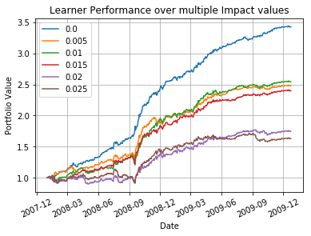

```python
# In Sample Charts
startdt = dt.datetime(2008,1,1)
enddt = dt.datetime(2009,12,31)
symbols = 'JPM'
startval = 100000
commission = 0.0

impacts = np.arange(0.0, 0.03, 0.005)

for impact in impacts:

    # Strategy Learner
    stratlearner = sl.StrategyLearner()
    stratlearner.addEvidence(symbols, startdt, enddt, startval)
    stratlearndf = stratlearner.testPolicy(symbols, startdt, enddt, startval)

    stratlearnport = pd.DataFrame(0, index = stratlearndf.index, columns = ["Symbol", "Order", "SharesCnt"])
    stratlearnport['Date'] = stratlearndf.index
    stratlearnport['Symbol'] = 'JPM'
    stratlearnport['Order'] = "BUY"
    for i in range(0, len(stratlearndf)-1):
        if stratlearndf.ix[i]['JPM'] == 1000:
            stratlearnport.ix[i,'Order'] = 'BUY'
            stratlearnport.ix[i,'SharesCnt'] = 1000
        elif stratlearndf.ix[i]['JPM'] == 2000:
            stratlearnport.ix[i,'Order'] = 'BUY'
            stratlearnport.ix[i,'SharesCnt'] = 2000
        elif stratlearndf.ix[i]['JPM'] == -1000:
            stratlearnport.ix[i,'Order'] = 'SELL'
            stratlearnport.ix[i,'SharesCnt'] = 1000
        elif stratlearndf.ix[i]['JPM'] == -2000:
            stratlearnport.ix[i,'Order'] = 'SELL'
            stratlearnport.ix[i,'SharesCnt'] = 2000
        else:
            stratlearnport.ix[i,'Order'] = 'NOTHING'
            stratlearnport.ix[i,'SharesCnt'] = 0

    stratlernportval = compute_portvals(stratlearnport,start_val=startval,commission=commission,impact=impact)
    normedstratlernportval = stratlernportval/stratlernportval.ix[0]

    daily_ret = (normedstratlernportval/normedstratlernportval.shift(1)) - 1
    cr = (normedstratlernportval[-1]/normedstratlernportval[0]) - 1
    adr = daily_ret.mean()
    sddr = daily_ret.std()

    print "Impact: {}".format(impact)
    print
    print "Cumulative Return of Strategy Learner Portfolio: {}".format(cr)
    print
    print "Standard Deviation of Strategy Learner Portfolio: {}".format(sddr)
    print
    print "Average Daily Return of Strategy Learner Portfolio: {}".format(adr)
    print


    plt.plot(normedstratlernportval)

plt.title('Learner Performance over multiple Impact values')
plt.ylabel('Portfolio Value')
plt.xlabel('Date')
plt.xticks(rotation=25)
plt.grid(True)
plt.legend(impacts)
plt.show()
```

Below table and graph shows the performance of strategy learner for various impact values. It can be observed that Strategy Learner performed much better for low value of impact, but performance degrades as impact increases. This observation is in line with our hypothesis.